# Métodos multivariados - Tarea 2

Elmer Calel - 201213600

29/3/2020

```r
# Librerías utilizadas
library(mvtnorm)
library(ggplot2)
library(GGally)
library(MVN)
library(boot)
library(vegan)
library(FactoMineR)
library(factoextra)
library(ggcorrplot)
library(corrplot)
library(readr)
library(psych)
library(polycor)
library(GPArotation)
```

## Problema 1:

- Con el comando rmvnorm de la librería mtvnorm generar una muestra de tamaño 1000 de una distribución normal tridimensional con vector de medias = 1,2,-5 y matriz de covarianzas sigma =
  $$\begin{array}{ll}
  1 & 1 & 0 \\
  1 & 2 & 0 \\
  0 & 0 & 5
  \end{array}$$

```r
mu <- c(1,2,-5)
mu
```

```
## [1]  1  2 -5
```

```r
sigma <- matrix(c(1,1,0,
                               1,2,0,
                               0,0,5), ncol = 3, byrow = F)
sigma
```

```
##      [,1] [,2] [,3]
## [1,]    1    1    0
## [2,]    1    2    0
## [3,]    0    0    5
```

- Fije el valor de la semilla a 34 y guarde el resultado de la muestra en una variable.

```r
set.seed(34)
```

- Utilice calcule el vector de medias de su muestra.

```r
dist_mult_norm <- rmvnorm(1000, mean = mu, sigma = sigma)
head(dist_mult_norm)
```

```
##           [,1]     [,2]      [,3]
## [1,] 1.4123457 3.547604 -6.671958
## [2,] 0.3676052 1.389109 -6.018511
## [3,] 1.2201299 1.160838 -2.614553
## [4,] 0.8131536 1.456143 -3.392026
## [5,] 1.3068214 3.323088 -4.102767
## [6,] 2.2217906 2.632391 -6.049650
```

```r
vector_medias <- colMeans(dist_mult_norm)
vector_medias
```

```
## [1]  0.9771058  1.9661702 -4.9980956
```

- Encuentre la matriz de covarianzas de su muestra con el comando cov

```r
cov(dist_mult_norm)
```

```
##             [,1]       [,2]         [,3]
## [1,] 0.974794361  1.0034763  0.003231379
## [2,] 1.003476286  2.0200676 -0.110589909
## [3,] 0.003231379 -0.1105899  4.646719781
```

- Aplique la prueba de Shapiro-Wilk a cada columna de su muestra para verificar normalidad en cada variable.

```r
plotn <- function(x,main="Histograma de frecuencias \ny distribución normal",
                  xlab="X",ylab="Densidad") {
  min <- min(x)
  max <- max(x)
  media <- mean(x)
  dt <- sd(x)
  hist(x,freq=F,main=main,xlab=xlab,ylab=ylab)
  curve(dnorm(x,media,dt), min, max,add = T,col="blue")
}

dist_mult_norm.v1 <- shapiro.test(dist_mult_norm[,1])
dist_mult_norm.v1
```

```
##
##  Shapiro-Wilk normality test
##
## data:  dist_mult_norm[, 1]
## W = 0.99823, p-value = 0.3951
```

```r
dist_mult_norm.v2 <- shapiro.test(dist_mult_norm[,2])
dist_mult_norm.v2
```

```
##
##  Shapiro-Wilk normality test
##
## data:  dist_mult_norm[, 2]
## W = 0.99918, p-value = 0.95
```

```r
dist_mult_norm.v3 <- shapiro.test(dist_mult_norm[,3])
dist_mult_norm.v3
```

```
##
##  Shapiro-Wilk normality test
##
## data:  dist_mult_norm[, 3]
## W = 0.999, p-value = 0.8715
```

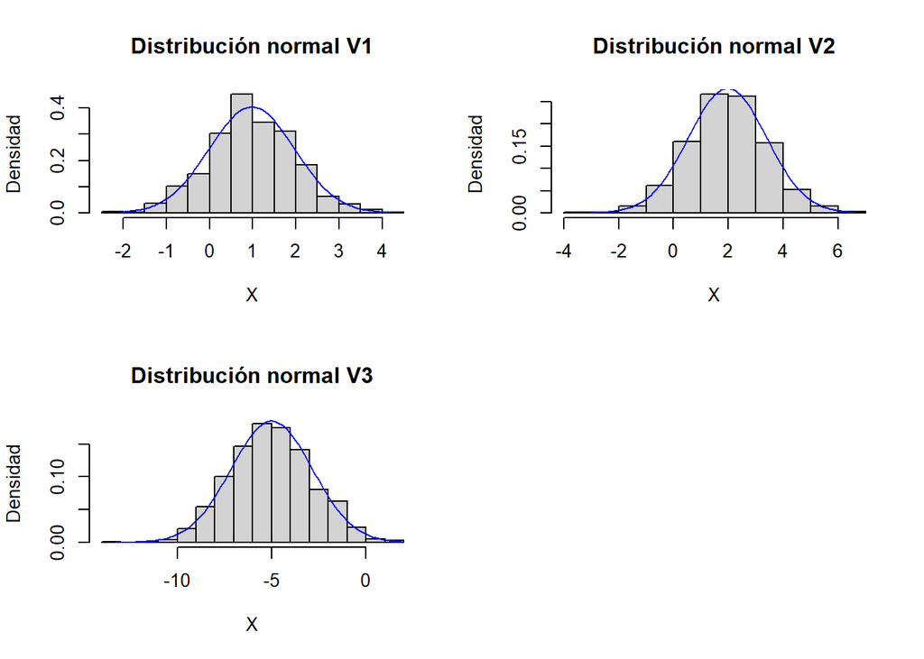

```r
par(mfrow=c(2,2))
plotn(dist_mult_norm[,1],main="Distribución normal V1")
plotn(dist_mult_norm[,2],main="Distribución normal V2")
plotn(dist_mult_norm[,3],main="Distribución normal V3")
```

- Grafique el conjunto de datos con el comando ggpairs de GGally.

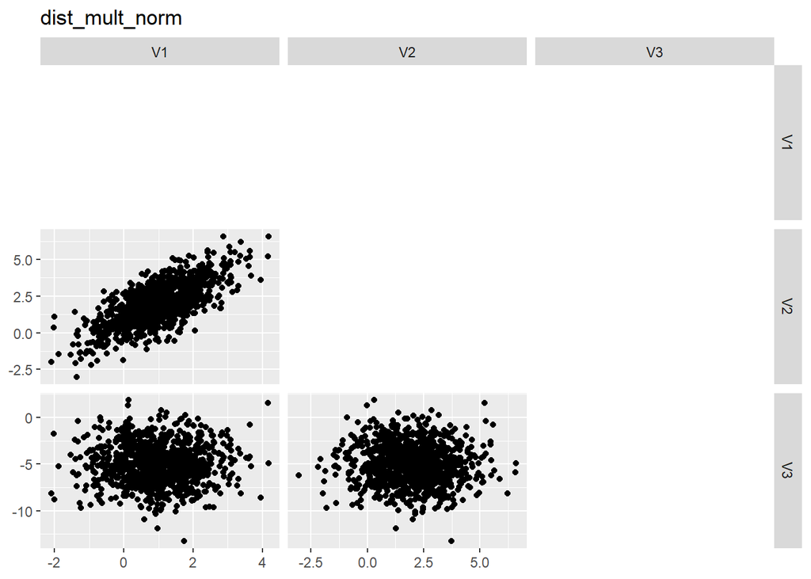

```r
ggpairs(as.data.frame(dist_mult_norm), title = "dist_mult_norm", diag = NULL, upper = NULL)
```

- Aplique la prueba de normalidad multivariada de MARDIA utilizando el comando mvn de la librería MVN, utilice la opción multivariatePlot = “qq”.

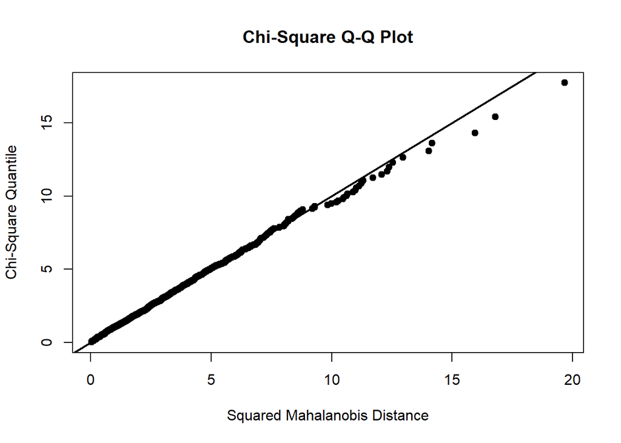

```
## $multivariateNormality
##              Test         Statistic           p value Result
## 1 Mardia Skewness  6.98751150786871 0.726623415483513    YES
## 2 Mardia Kurtosis 0.948874775336082 0.342684305226329    YES
## 3             MVN              <NA>              <NA>    YES
##
## $univariateNormality
##           Test  Variable Statistic   p value Normality
## 1 Shapiro-Wilk  Column1     0.9982    0.3951    YES
## 2 Shapiro-Wilk  Column2     0.9992    0.9500    YES
## 3 Shapiro-Wilk  Column3     0.9990    0.8715    YES
##
## $Descriptives
##      n       Mean   Std.Dev    Median        Min      Max       25th      75th
## 1 1000  0.9771058 0.9873167  0.943471  -2.091388 4.175309  0.3415848  1.672130
## 2 1000  1.9661702 1.4212908  1.975340  -3.038739 6.589247  1.0561018  2.891861
## 3 1000 -4.9980956 2.1556251 -5.041694 -13.268468 1.853098 -6.4695312 -3.545997
##          Skew    Kurtosis
## 1  0.01139466  0.12693656
## 2 -0.02816485  0.14358986
## 3  0.02105720 -0.04617196
```

```r
mvn(dist_mult_norm, mvnTest = "mardia", multivariatePlot = "qq")
```

## Problema 2

Para este ejercicio utilizara el conjunto de datos frets(dimensiones de longitud y ancho de cabeza del primer y segundo hijo) del paquete boot.

```r
frets
```

```
##     l1  b1  l2  b2
## 1  191 155 179 145
## 2  195 149 201 152
## 3  181 148 185 149
## 4  183 153 188 149
## 5  176 144 171 142
## 6  208 157 192 152
## 7  189 150 190 149
## 8  197 159 189 152
## 9  188 152 197 159
## 10 192 150 187 151
## 11 179 158 186 148
## 12 183 147 174 147
## 13 174 150 185 152
## 14 190 159 195 157
## 15 188 151 187 158
## 16 163 137 161 130
## 17 195 155 183 158
## 18 186 153 173 148
## 19 181 145 182 146
## 20 175 140 165 137
## 21 192 154 185 152
## 22 174 143 178 147
## 23 176 139 176 143
## 24 197 167 200 158
## 25 190 163 187 150
```

- Grafique los datos con ggpairs

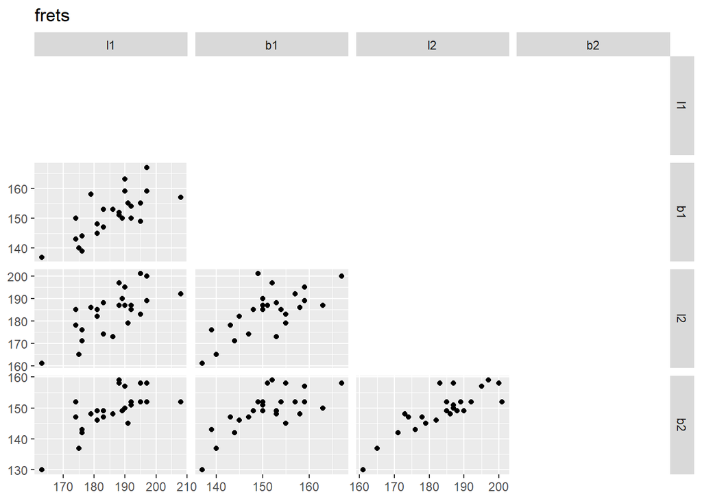

```r
ggpairs(frets, title = "frets", diag = NULL, upper = NULL)
```

- ¿EL conjunto de datos presenta normalidad multivariada?

```r
mvn(frets, multivariatePlot = "pp")
```

```
## $multivariateNormality
##              Test          Statistic           p value Result
## 1 Mardia Skewness   20.0675048518331 0.453714137536159    YES
## 2 Mardia Kurtosis -0.395037104219128  0.69281550505138    YES
## 3             MVN               <NA>              <NA>    YES
##
## $univariateNormality
##           Test  Variable Statistic   p value Normality
## 1 Shapiro-Wilk    l1        0.9779    0.8407    YES
## 2 Shapiro-Wilk    b1        0.9887    0.9911    YES
## 3 Shapiro-Wilk    l2        0.9706    0.6607    YES
## 4 Shapiro-Wilk    b2        0.9238    0.0627    YES
##
## $Descriptives
##     n   Mean   Std.Dev Median Min Max 25th 75th        Skew   Kurtosis
## l1 25 185.72  9.761830    188 163 208  179  192 -0.09388303 -0.1951972
## b1 25 151.12  7.372923    151 137 167  147  155  0.01330230 -0.5559836
## l2 25 183.84 10.040252    185 161 201  178  189 -0.38369217 -0.3957571
## b2 25 149.24  6.709943    149 130 159  147  152 -0.81963151  0.8457927
```

Según los resultados obtenidos, el conjnto de datos si presenta normalidad multivariada.

- ¿Qué variables se comportan de forma normal?

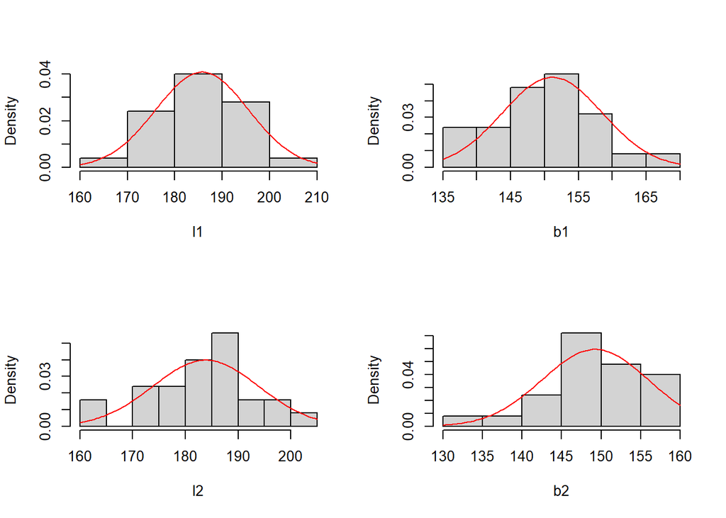

```
## $multivariateNormality
##      Test        H   p value MVN
## 1 Royston 3.944112 0.3587247 YES
##
## $univariateNormality
##                              Test  Variable Statistic   p value Normality
## 1 Lilliefors (Kolmogorov-Smirnov)    l1        0.1123    0.5732    YES
## 2 Lilliefors (Kolmogorov-Smirnov)    b1        0.0796    0.9503    YES
## 3 Lilliefors (Kolmogorov-Smirnov)    l2        0.1460    0.1840    YES
## 4 Lilliefors (Kolmogorov-Smirnov)    b2        0.1404    0.2302    YES
##
## $Descriptives
##     n   Mean   Std.Dev Median Min Max 25th 75th        Skew   Kurtosis
## l1 25 185.72  9.761830    188 163 208  179  192 -0.09388303 -0.1951972
## b1 25 151.12  7.372923    151 137 167  147  155  0.01330230 -0.5559836
## l2 25 183.84 10.040252    185 161 201  178  189 -0.38369217 -0.3957571
## b2 25 149.24  6.709943    149 130 159  147  152 -0.81963151  0.8457927
```

```r
mvn(frets, mvnTest = "royston", univariateTest = "Lillie", desc = TRUE, univariatePlot = "histogram")
```

Las variables que presentan normalidad son l1, b1, l2 y b2.

- Grafique la matriz de correlaciones

```r
cor(frets)
```

```
##           l1        b1        l2        b2
## l1 1.0000000 0.7345555 0.7107518 0.7039807
## b1 0.7345555 1.0000000 0.6931573 0.7085504
## l2 0.7107518 0.6931573 1.0000000 0.8392519
## b2 0.7039807 0.7085504 0.8392519 1.0000000
```

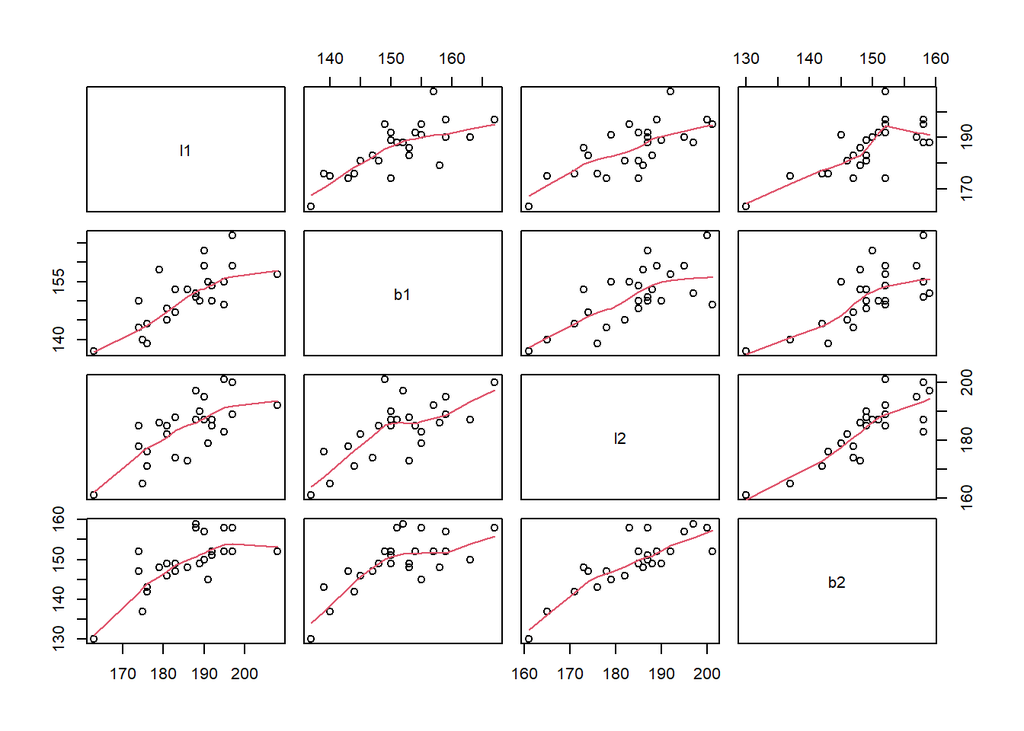

```r
pairs(frets, panel=panel.smooth, cex.labels = 1, font.labels=1)
```

- Calcule la correlación múltiple de (l2,b2) con l1

```r
modelo <- lm(frets$l1~frets$l2 + frets$b2)
cor(frets$l1,modelo$fitted.values)
```

```
## [1] 0.7377269
```

- Encuentre la correlación múltiple de (l2,b2) con b1

```r
modelo <- lm(frets$l1~frets$l2 + frets$b2)
cor(frets$b1,modelo$fitted.values)
```

```
## [1] 0.730304
```

- Calcule las correlaciones canónicas de (l1,b1) con (l2,b2)

```r
x = frets[,1:2]
y = frets[,3:4]
x
```

```
##     l1  b1
## 1  191 155
## 2  195 149
## 3  181 148
## 4  183 153
## 5  176 144
## 6  208 157
## 7  189 150
## 8  197 159
## 9  188 152
## 10 192 150
## 11 179 158
## 12 183 147
## 13 174 150
## 14 190 159
## 15 188 151
## 16 163 137
## 17 195 155
## 18 186 153
## 19 181 145
## 20 175 140
## 21 192 154
## 22 174 143
## 23 176 139
## 24 197 167
## 25 190 163
```

```r
CCorA(x,y)
```

```
##
## Canonical Correlation Analysis
##
## Call:
## CCorA(Y = x, X = y)
##
##              Y X
## Matrix Ranks 2 2
##
## Pillai's trace:  0.6246327
##
## Significance of Pillai's trace:
## from F-distribution:   0.0020825
##                        CanAxis1 CanAxis2
## Canonical Correlations  0.78851   0.0537
##
##                      Y | X  X | Y
## RDA R squares      0.54083 0.5707
## adj. RDA R squares 0.49909 0.5317
```

## Problema 3

En este problema analizara el conjunto de datos USArrests. Necesitará utilizar las librerías FactoMineR, factoextra

```r
head(USArrests)
```

```
##            Murder Assault UrbanPop Rape
## Alabama      13.2     236       58 21.2
## Alaska       10.0     263       48 44.5
## Arizona       8.1     294       80 31.0
## Arkansas      8.8     190       50 19.5
## California    9.0     276       91 40.6
## Colorado      7.9     204       78 38.7
```

```r
str(USArrests)
```

```
## 'data.frame':    50 obs. of  4 variables:
##  $ Murder  : num  13.2 10 8.1 8.8 9 7.9 3.3 5.9 15.4 17.4 ...
##  $ Assault : int  236 263 294 190 276 204 110 238 335 211 ...
##  $ UrbanPop: int  58 48 80 50 91 78 77 72 80 60 ...
##  $ Rape    : num  21.2 44.5 31 19.5 40.6 38.7 11.1 15.8 31.9 25.8 ...
```

- Utilice el comando PCA para hacer un objeto con todo el análisis de componentes principales el conjunto de datos USArrest. Guarde este objeto en una variable llamada pca_usarrest

```r
pca_usarrest <- PCA(USArrests, graph = F)
var <- get_pca_var(pca_usarrest)
ind <- get_pca_ind(pca_usarrest)
```

- Dibuje el Scree plot, para las componentes principales

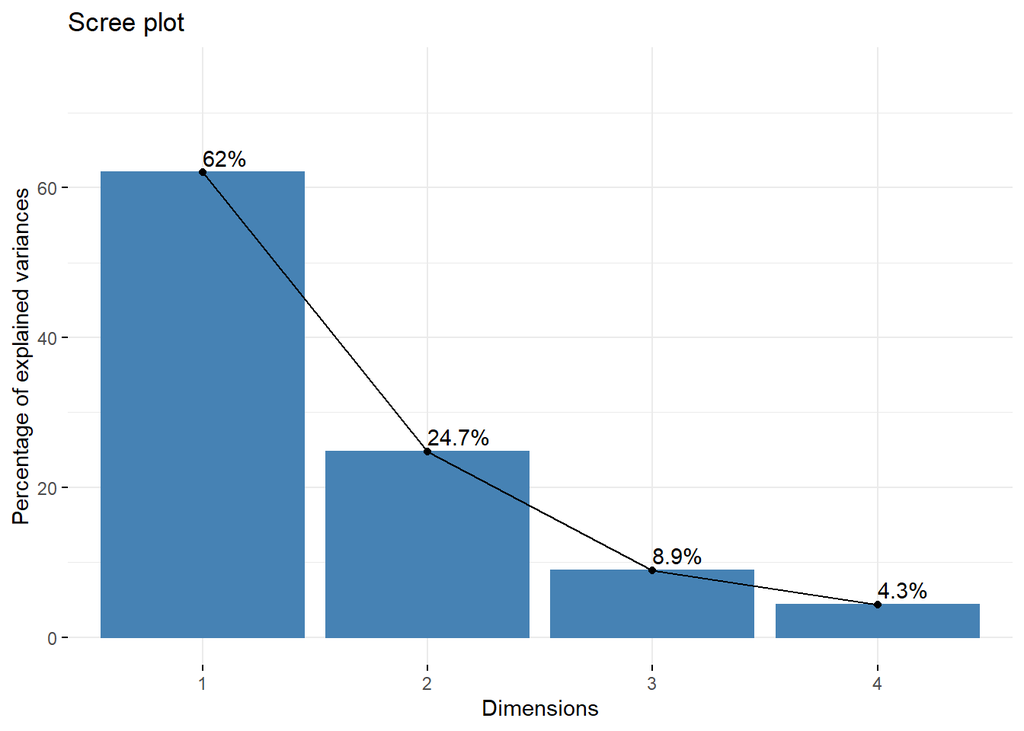

```r
fviz_screeplot(pca_usarrest,addlabels=T,ylim=c(0,75))
```

- Imprima pca_usarrest$eig

```r
pca_usarrest$eig
```

```
##        eigenvalue percentage of variance cumulative percentage of variance
## comp 1  2.4802416              62.006039                          62.00604
## comp 2  0.9897652              24.744129                          86.75017
## comp 3  0.3565632               8.914080                          95.66425
## comp 4  0.1734301               4.335752                         100.00000
```

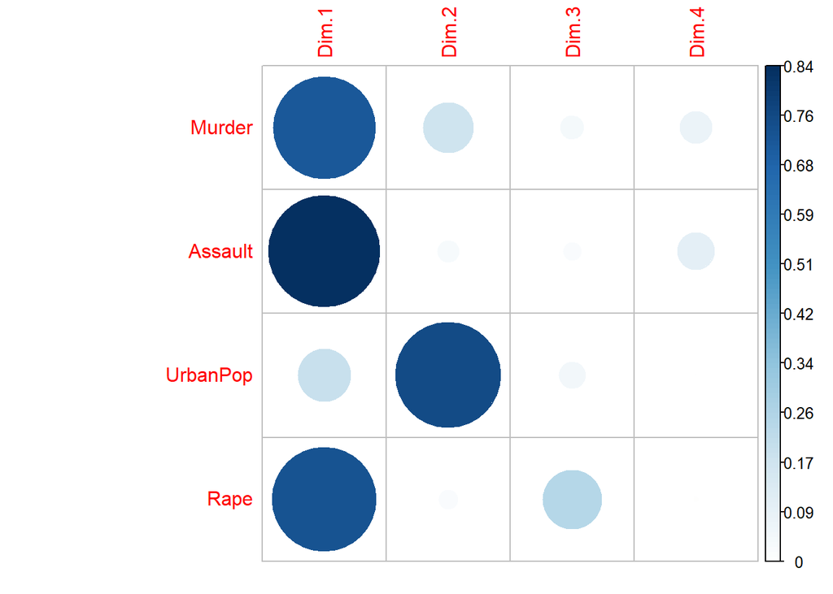

```r
corrplot(var$cos2,is.corr = F)
```

- Dibuje el grafico de contribuciones de las componentes para cada variable.

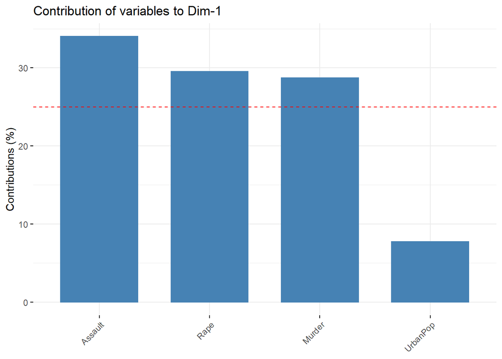

```r
fviz_contrib(pca_usarrest,choice = "var",axes = 1)
```

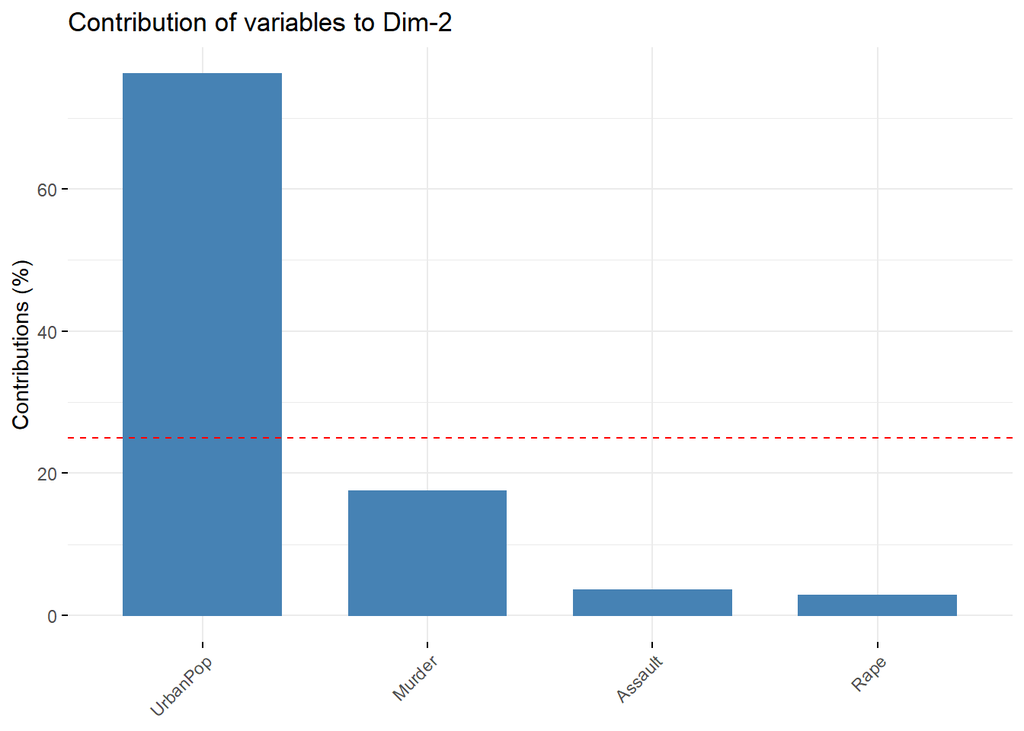

```r
fviz_contrib(pca_usarrest,choice = "var",axes = 2)
```

- Grafique las variables.

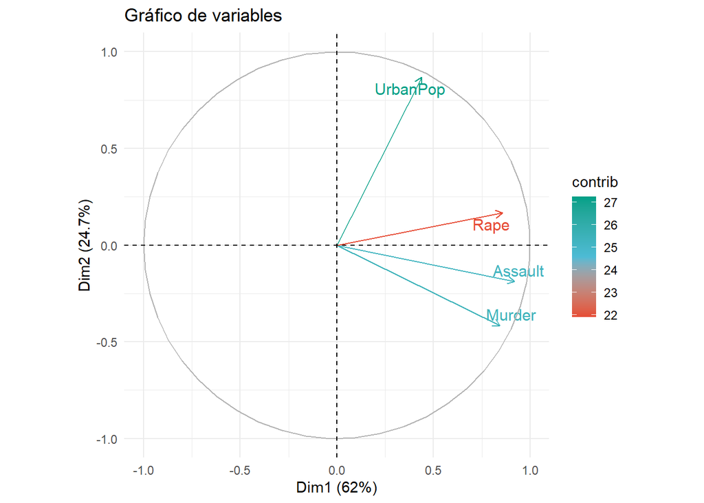

```r
fviz_pca_var(pca_usarrest,col.var="contrib",
             gradient.col="npg",repel = T)+ggtitle("Gráfico de variables")+theme_minimal()
```

- Grafique a los individuos.

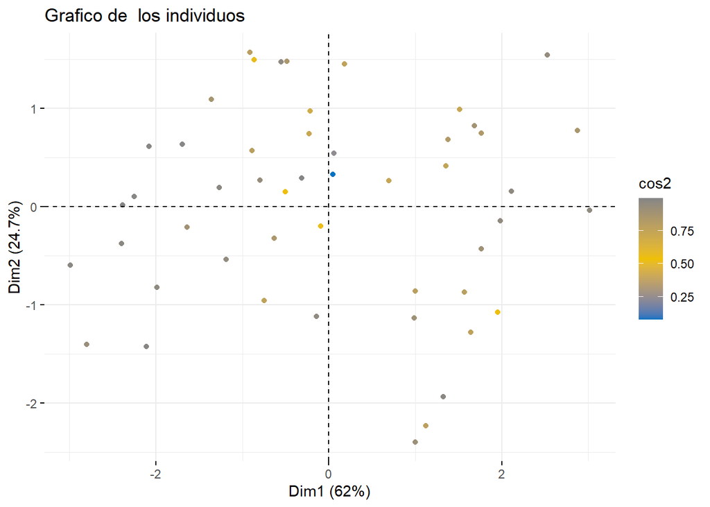

```r
fviz_pca_ind(pca_usarrest,geom.ind = "point",
             col.ind="cos2",gradient.col="jco") + ggtitle("Grafico de  los individuos")
```

- Grafique variables e individuos.

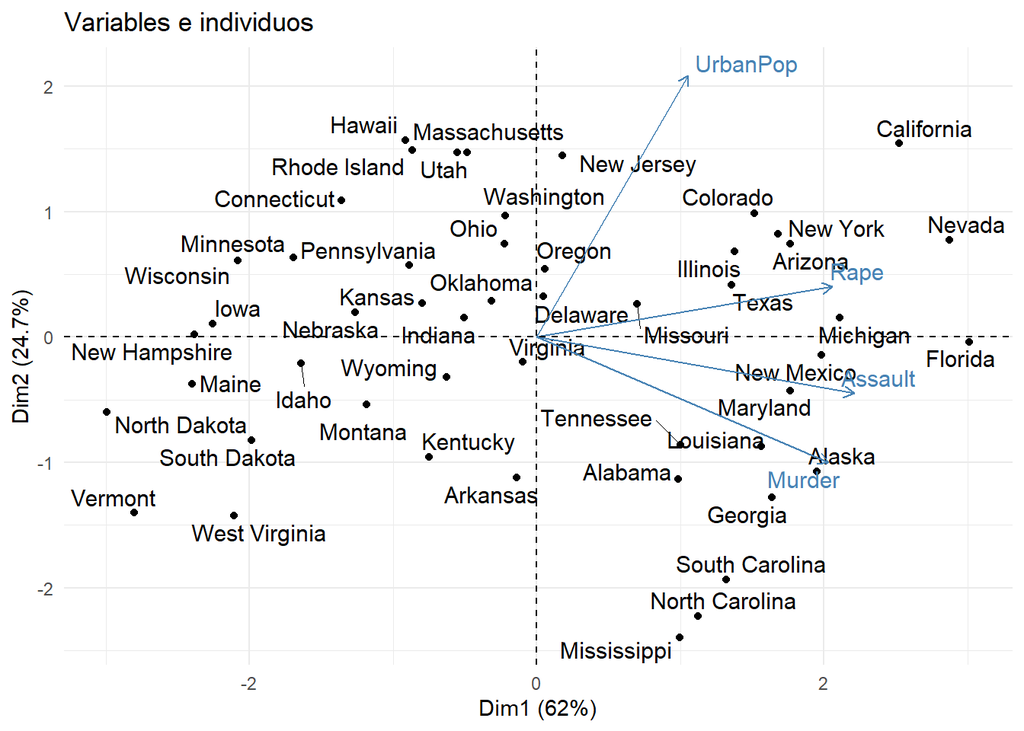

```r
fviz_pca_biplot(pca_usarrest,var="contrib",
                palette =  "uchicago" ,repel = T)+ggtitle("Variables e individuos")+theme_minimal()
```

- Si necesita tener un nuevo conjunto de datos que presente el 80% de la varianza del conjunto original ¿Cuántas componentes debe utilizar?

**Se necesitan 2 componentes, según el Screen plot de las componentes principales.**

- Escriba las ecuaciones necesarias para la transformación con dos componentes

Dado que
$$Y = XT$$
es lo que se llama transformación por componentes princiapales.

Primero se debe calcular el vector de medias y la matriz de varianzas. Luego se obtienen los valores porpios y sus respectivos vetores propios.

## Problema 4

Para este problema utilizara el conjunto de datos estilos.csv (cuestionario con 32 preguntas acerca del humor) su objetivo es reducir el conjunto de datos de las 32 preguntas

```r
estilos <- read_delim("../Data/estilos.csv",
    ";", escape_double = FALSE, trim_ws = TRUE)
str(estilos)
```

```
## tibble [1,071 x 39] (S3: spec_tbl_df/tbl_df/tbl/data.frame)
##  $ Q1           : num [1:1071] 2 2 3 3 1 3 4 2 2 4 ...
##  $ Q2           : num [1:1071] 2 3 4 3 4 3 1 4 2 2 ...
##  $ Q3           : num [1:1071] 3 2 3 3 2 3 2 4 1 4 ...
##  $ Q4           : num [1:1071] 1 2 3 4 2 2 4 1 1 1 ...
##  $ Q5           : num [1:1071] 4 4 4 3 3 3 2 5 3 3 ...
##  $ Q6           : num [1:1071] 5 4 4 5 5 3 3 5 4 5 ...
##  $ Q7           : num [1:1071] 4 4 3 4 4 4 3 4 3 4 ...
##  $ Q8           : num [1:1071] 3 3 1 3 1 2 3 3 1 2 ...
##  $ Q9           : num [1:1071] 4 4 2 -1 4 2 4 2 3 3 ...
##  $ Q10          : num [1:1071] 3 3 4 4 4 1 4 4 3 1 ...
##  $ Q11          : num [1:1071] 3 4 3 2 2 3 4 3 2 5 ...
##  $ Q12          : num [1:1071] 1 3 2 4 2 3 1 3 2 3 ...
##  $ Q13          : num [1:1071] 5 3 4 4 5 4 2 5 5 1 ...
##  $ Q14          : num [1:1071] 4 4 4 5 4 4 1 4 3 3 ...
##  $ Q15          : num [1:1071] 4 5 3 4 4 4 2 3 3 1 ...
##  $ Q16          : num [1:1071] 4 4 3 3 4 3 4 3 4 5 ...
##  $ Q17          : num [1:1071] 2 2 2 3 2 2 4 3 2 5 ...
##  $ Q18          : num [1:1071] 3 2 4 3 3 1 1 4 2 1 ...
##  $ Q19          : num [1:1071] 3 3 2 3 2 4 3 5 4 3 ...
##  $ Q20          : num [1:1071] 1 2 1 3 1 2 1 3 1 1 ...
##  $ Q21          : num [1:1071] 4 3 4 4 5 4 3 4 4 2 ...
##  $ Q22          : num [1:1071] 4 3 2 3 3 4 2 3 4 1 ...
##  $ Q23          : num [1:1071] 3 4 4 2 3 4 2 3 4 5 ...
##  $ Q24          : num [1:1071] 2 2 3 4 1 2 3 1 2 2 ...
##  $ Q25          : num [1:1071] 1 2 2 2 1 2 4 1 1 4 ...
##  $ Q26          : num [1:1071] 3 5 4 4 5 3 3 4 3 5 ...
##  $ Q27          : num [1:1071] 2 1 3 2 2 2 2 2 4 5 ...
##  $ Q28          : num [1:1071] 4 2 3 2 3 4 2 4 4 2 ...
##  $ Q29          : num [1:1071] 2 4 2 4 2 3 3 1 1 1 ...
##  $ Q30          : num [1:1071] 4 4 5 5 5 4 3 5 5 5 ...
##  $ Q31          : num [1:1071] 2 3 4 3 4 3 4 2 2 3 ...
##  $ Q32          : num [1:1071] 2 1 2 3 2 3 4 2 1 2 ...
##  $ affiliative  : num [1:1071] 4 3.3 3.9 3.6 4.1 3.6 2.3 4.4 4.1 2.4 ...
##  $ selfenhancing: num [1:1071] 3.5 3.5 3.9 4 4.1 2.9 2.3 4.1 3.3 2.9 ...
##  $ agressive    : num [1:1071] 3 3.3 3.1 2.9 2.9 3.4 2.8 3.3 2.9 3.8 ...
##  $ selfdefeating: num [1:1071] 2.3 2.4 2.3 3.3 2 2.6 2.8 2.5 2 2.3 ...
##  $ age          : num [1:1071] 25 44 50 30 52 30 27 34 30 18 ...
##  $ gender       : num [1:1071] 2 2 1 2 1 2 1 1 2 1 ...
##  $ accuracy     : num [1:1071] 100 90 75 85 80 60 60 88 95 85 ...
```

[output cut: 27 more lines]

[output not shown]

```r
head(estilos)
```

```
## # A tibble: 6 x 39
##      Q1    Q2    Q3    Q4    Q5    Q6    Q7    Q8    Q9   Q10   Q11   Q12   Q13
##   <dbl> <dbl> <dbl> <dbl> <dbl> <dbl> <dbl> <dbl> <dbl> <dbl> <dbl> <dbl> <dbl>
## 1     2     2     3     1     4     5     4     3     4     3     3     1     5
## 2     2     3     2     2     4     4     4     3     4     3     4     3     3
## 3     3     4     3     3     4     4     3     1     2     4     3     2     4
## 4     3     3     3     4     3     5     4     3    -1     4     2     4     4
## 5     1     4     2     2     3     5     4     1     4     4     2     2     5
## 6     3     3     3     2     3     3     4     2     2     1     3     3     4
## # ... with 26 more variables: Q14 <dbl>, Q15 <dbl>, Q16 <dbl>, Q17 <dbl>,
## #   Q18 <dbl>, Q19 <dbl>, Q20 <dbl>, Q21 <dbl>, Q22 <dbl>, Q23 <dbl>,
## #   Q24 <dbl>, Q25 <dbl>, Q26 <dbl>, Q27 <dbl>, Q28 <dbl>, Q29 <dbl>,
## #   Q30 <dbl>, Q31 <dbl>, Q32 <dbl>, affiliative <dbl>, selfenhancing <dbl>,
## #   agressive <dbl>, selfdefeating <dbl>, age <dbl>, gender <dbl>,
## #   accuracy <dbl>
```

```r
esitlos_f <- estilos[,1:36]
```

- Verifique que el conjunto de datos sea factorizable, para ello, grafique la matriz de correlaciones policorica, aplique la prueba de Bartlett y el criterio Kaiser-Meyer-Olkin.

Matriz de correlación policorica

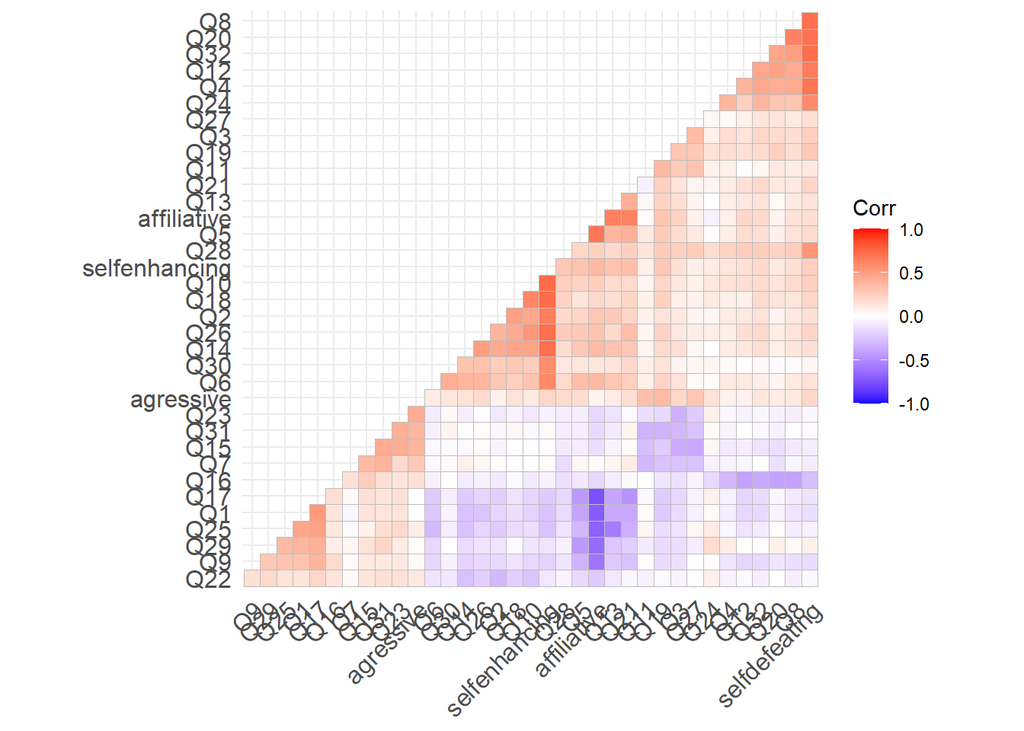

```r
mat_cor <- hetcor(esitlos_f)$correlations
ggcorrplot(mat_cor,type="lower",hc.order = T)
```

Prueba de Bartlett

```r
cortest.bartlett(mat_cor)->p_esf
p_esf$p
```

```
## [1] 4.223138e-268
```

Según el valor se rechaza la hipotesis nula de que los datos no están correlacionadas.

Prueba de Kaiser-Meyer-Olkin (KMO)

```r
KMO(mat_cor)
```

```
## Kaiser-Meyer-Olkin factor adequacy
## Call: KMO(r = mat_cor)
## Overall MSA =  0.2
## MSA for each item =
##            Q1            Q2            Q3            Q4            Q5
##          0.26          0.20          0.14          0.17          0.27
##            Q6            Q7            Q8            Q9           Q10
##          0.20          0.09          0.21          0.18          0.24
##           Q11           Q12           Q13           Q14           Q15
##          0.09          0.18          0.27          0.24          0.13
##           Q16           Q17           Q18           Q19           Q20
##          0.12          0.28          0.22          0.18          0.20
##           Q21           Q22           Q23           Q24           Q25
##          0.26          0.08          0.11          0.11          0.27
##           Q26           Q27           Q28           Q29           Q30
##          0.24          0.10          0.15          0.19          0.12
##           Q31           Q32   affiliative selfenhancing     agressive
##          0.13          0.21          0.40          0.33          0.13
## selfdefeating
##          0.29
```

En este caso el resultado es 0.2, que segun valores de referencia está en en el rengo inaceptable.

- Grafique el scree plot y efectué un análisis paralelo para ver el número necesario de factores.

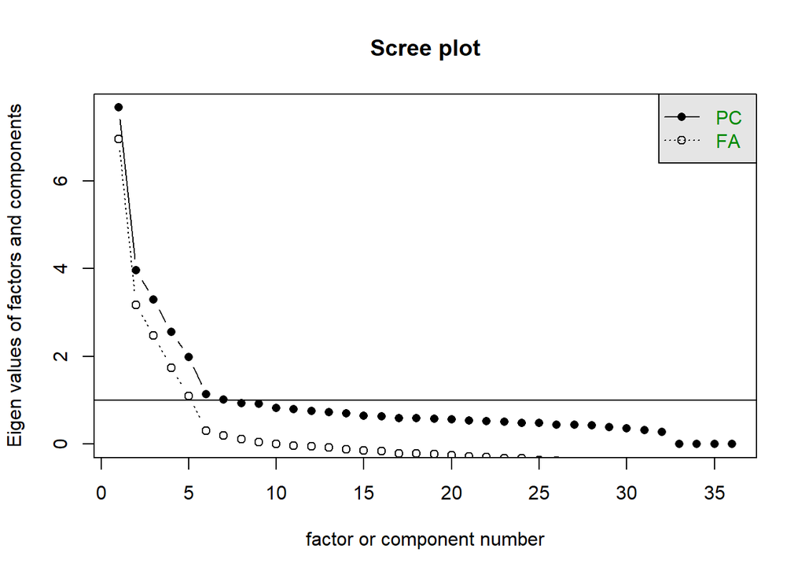

```r
scree(mat_cor)
```

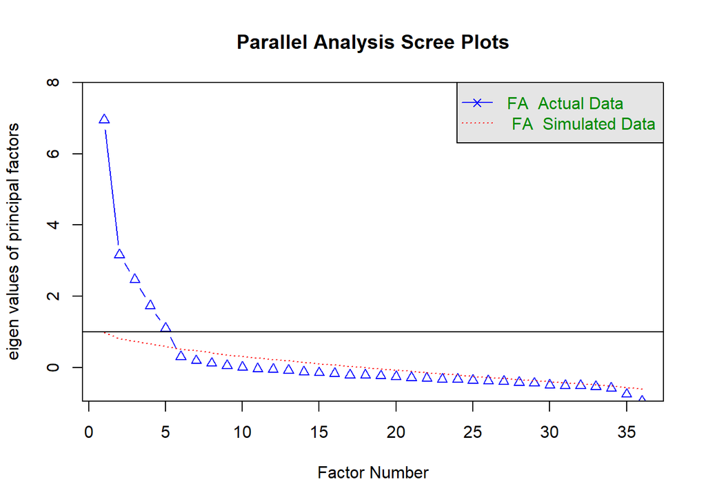

```
## Parallel analysis suggests that the number of factors =  5  and the number of components =  NA
```

```r
fa.parallel(mat_cor,n.obs=200,fa="fa",fm="minres")
```

- ¿Cuántos factores puede utilizar para representar el conjunto de datos?

Según los resultados obtenidos por el screen plot, se pueden utilizar 5 factores para repesentar el conjunto de datos.

- Realice una reducción del conjunto de datos utilizando 4 factores llamados Autoesfuerzo, afiliativo, agresivo, defensivo, utilice el método minres, con rotación varimax.

```r
modelo <- fa(estilos[,33:36], nfactors = 4, rotate = "varimax", fm="minres")
modelo
```

```
## Factor Analysis using method =  minres
## Call: fa(r = estilos[, 33:36], nfactors = 4, rotate = "varimax", fm = "minres")
## Standardized loadings (pattern matrix) based upon correlation matrix
##                MR1  MR2   MR3 MR4   h2   u2 com
## affiliative   0.62 0.05  0.09   0 0.39 0.61 1.1
## selfenhancing 0.58 0.33 -0.08   0 0.46 0.54 1.6
## agressive     0.05 0.51 -0.04   0 0.27 0.73 1.0
## selfdefeating 0.22 0.40  0.15   0 0.23 0.77 1.9
##
##                        MR1  MR2  MR3  MR4
## SS loadings           0.77 0.54 0.04 0.00
## Proportion Var        0.19 0.13 0.01 0.00
## Cumulative Var        0.19 0.33 0.34 0.34
## Proportion Explained  0.57 0.40 0.03 0.00
## Cumulative Proportion 0.57 0.97 1.00 1.00
##
## Mean item complexity =  1.4
## Test of the hypothesis that 4 factors are sufficient.
##
## The degrees of freedom for the null model are  6  and the objective function was  0.29 with Chi Square of  312.86
## The degrees of freedom for the model are -4  and the objective function was  0
##
## The root mean square of the residuals (RMSR) is  0
## The df corrected root mean square of the residuals is  NA
##
## The harmonic number of observations is  1071 with the empirical chi square  0  with prob <  NA
## The total number of observations was  1071  with Likelihood Chi Square =  0  with prob <  NA
##
## Tucker Lewis Index of factoring reliability =  1.02
## Fit based upon off diagonal values = 1
## Measures of factor score adequacy
##                                                    MR1   MR2   MR3 MR4
## Correlation of (regression) scores with factors   0.73  0.62  0.23   0
## Multiple R square of scores with factors          0.53  0.39  0.05   0
## Minimum correlation of possible factor scores     0.07 -0.22 -0.89  -1
```

- Dibuje un biplot de dos factores.

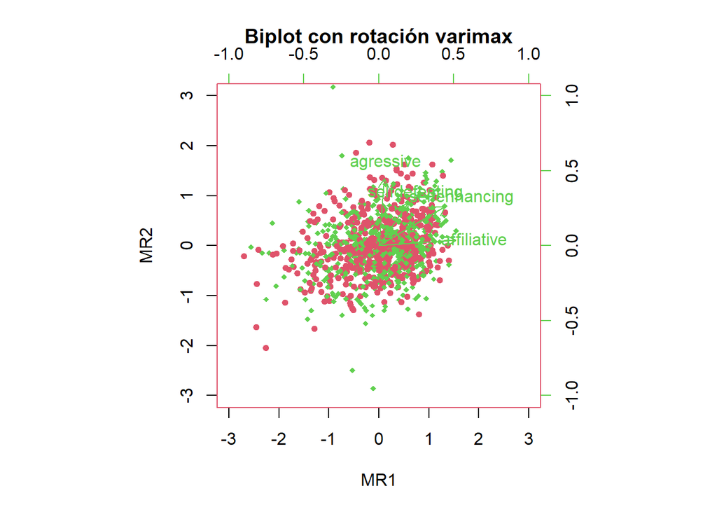

```r
biplot.psych(fa(estilos[,33:36], nfactors = 2, fm="minres", rotate = "varimax"), main = "Biplot con rotación varimax", col = c(2,3,4), pch = c(21,18), group = c(1,2))
```

- Imprima las comunidades y las unicidades.

```r
c1 <- sort(modelo$communality,decreasing = T)
head(cbind(c1))
```

```
##                      c1
## selfenhancing 0.4580260
## affiliative   0.3923348
## agressive     0.2698712
## selfdefeating 0.2302701
```

```r
u1 <- sort(modelo$uniquenesses,decreasing = T)
head(cbind(u1))
```

```
##                      u1
## selfdefeating 0.7697299
## agressive     0.7301288
## affiliative   0.6076652
## selfenhancing 0.5419740
```

- Imprima un diagrama que explique el análisis factorial.

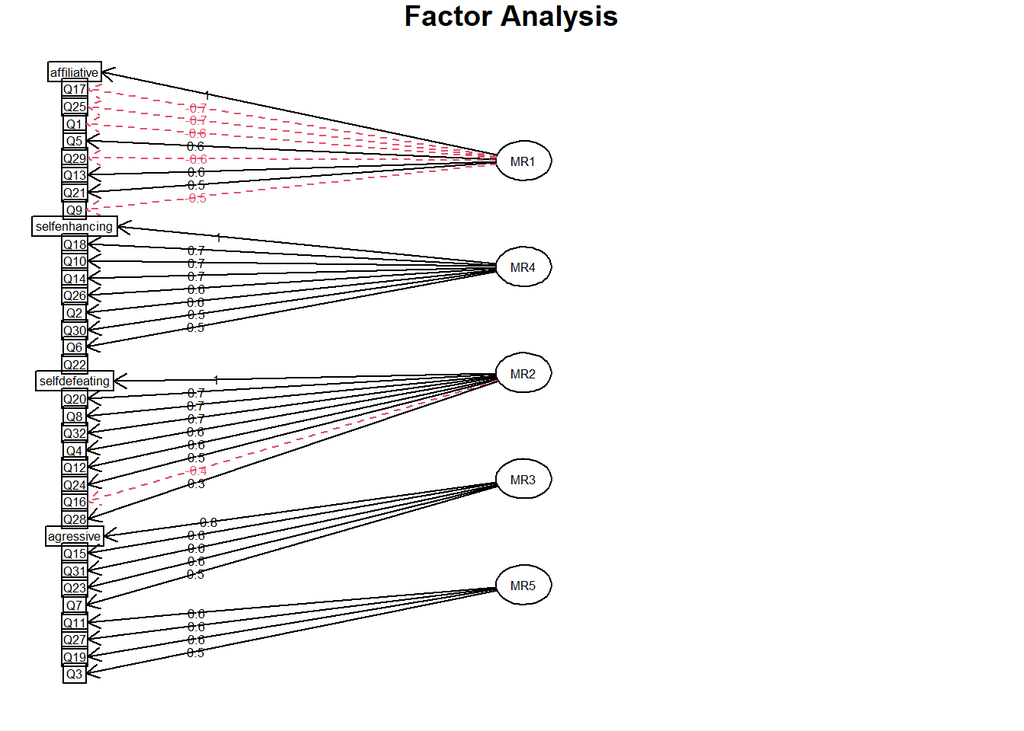

```r
modelo_varimax<-fa(mat_cor,nfactors = 5,rotate = "varimax", fa="minres")
fa.diagram(modelo_varimax)
```